# Analytics 512: In-Class 1/30/18

## 1. Interactions

## 2. Nonlinear Transformations of Predictors

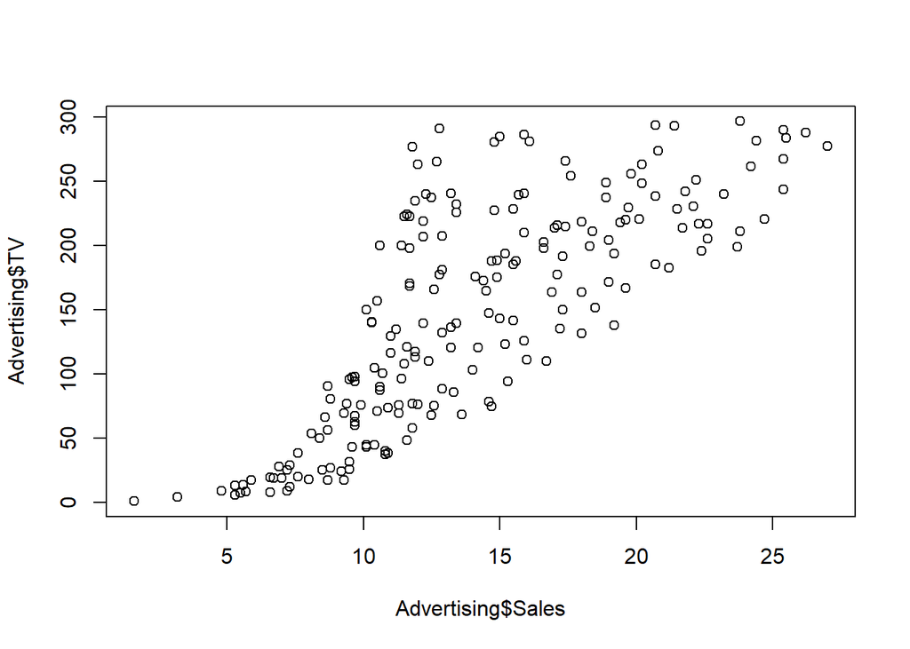

```r
Advertising <- read.csv("./Advertising.csv")
plot(Advertising$Sales, Advertising$TV)
```

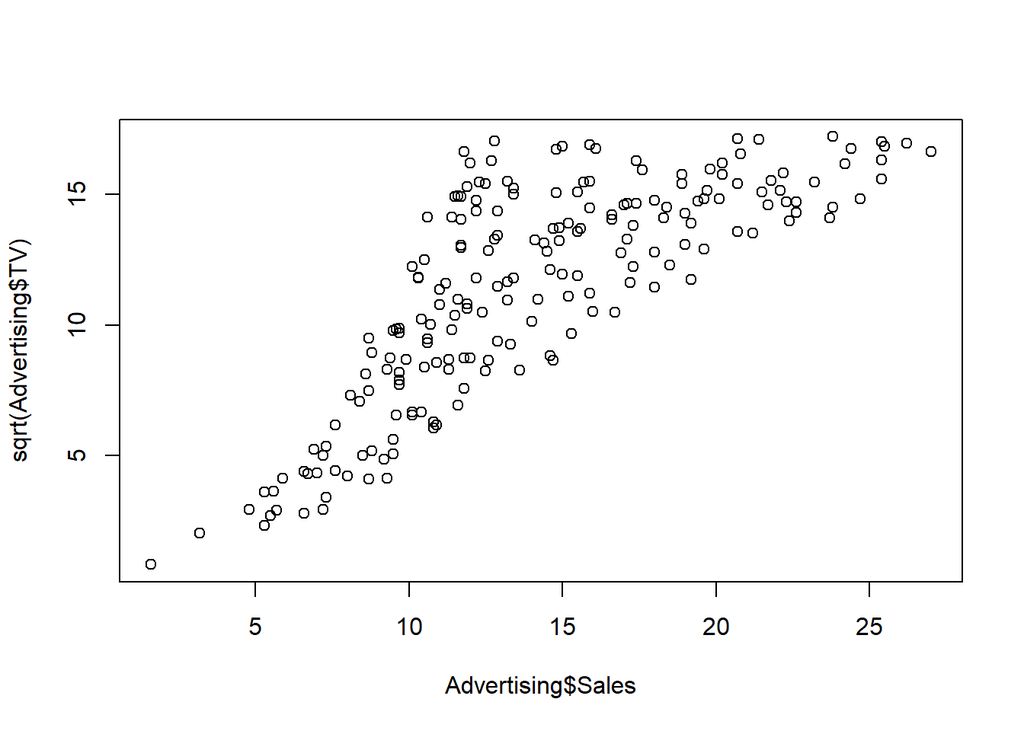

```r
plot(Advertising$Sales, sqrt(Advertising$TV))
```

```r
testlm <- lm(Sales ~ TV + sqrt(TV), data = Advertising)
summary(testlm)
```

```
##
## Call:
## lm(formula = Sales ~ TV + sqrt(TV), data = Advertising)
##
## Residuals:
##     Min      1Q  Median      3Q     Max
## -7.7251 -1.8415 -0.1955  1.8805  7.4680
##
## Coefficients:
##             Estimate Std. Error t value Pr(>|t|)
## (Intercept)  3.75799    1.34823   2.787  0.00583 **
## TV           0.01275    0.01375   0.927  0.35515
## sqrt(TV)     0.73581    0.28546   2.578  0.01068 *
## ---
## Signif. codes:  0 '***' 0.001 '**' 0.01 '*' 0.05 '.' 0.1 ' ' 1
##
## Residual standard error: 3.213 on 197 degrees of freedom
## Multiple R-squared:  0.6245, Adjusted R-squared:  0.6207
## F-statistic: 163.8 on 2 and 197 DF,  p-value: < 2.2e-16
```

```r
# Try a few other nonlinear transformations and interactions.

testlm <- lm(Sales ~ sqrt(TV) + Radio + Newspaper, data = Advertising)
summary(testlm)
```

```
##
## Call:
## lm(formula = Sales ~ sqrt(TV) + Radio + Newspaper, data = Advertising)
##
## Residuals:
##     Min      1Q  Median      3Q     Max
## -5.3147 -0.8536  0.0294  0.8485  3.4205
##
## Coefficients:
##               Estimate Std. Error t value Pr(>|t|)
## (Intercept) -1.6092798  0.3362200  -4.786 3.34e-06 ***
## sqrt(TV)     0.9749476  0.0240384  40.558  < 2e-16 ***
## Radio        0.1947679  0.0071549  27.222  < 2e-16 ***
## Newspaper   -0.0005253  0.0048803  -0.108    0.914
## ---
## Signif. codes:  0 '***' 0.001 '**' 0.01 '*' 0.05 '.' 0.1 ' ' 1
##
## Residual standard error: 1.401 on 196 degrees of freedom
## Multiple R-squared:  0.929,  Adjusted R-squared:  0.9279
## F-statistic: 854.3 on 3 and 196 DF,  p-value: < 2.2e-16
```

```r
testlm <- lm(Sales ~ sqrt(TV) + Radio + sqrt(TV*Radio), data = Advertising)

testlm <- lm(Sales ~ sqrt(TV) +  sqrt(TV*Radio) + sqrt(Newspaper), data = Advertising)

testlm <- lm(Sales ~ TV + Newspaper/(Radio+1), data = Advertising)
```

## 3. Group exercise, Polynomial Regression

In this exercise, we’ll explore polynomial regression techniques for fitting nonlinear data.

1. Generate a synthetic dataset where $y$ is drawn from a quadratic polynomial of $x$ with additional of Gaussian noise.
2. Write a function that takes in a matrix $X$ and a vector $Y$ and returns the OLS solution for the betas. Do this using the explicit formula, $(X^{T}X)^{-1}X^{T}Y$.
3. Construct a design matrix $X$ for a simple model $Y = \beta_0 + \beta_1 X$. Remember: there are two columns in the design matrix, what is in the column corresponding to $\beta_0$?
4. Solve the simple model using your OLS function. Evaluate the model parameters as well as how “well” the model captures the variance in the data (compute RSS).
5. Create a new model matrix $X$ with a new predictor column corresponding to $x^2$. Solve this model. Do your estimated Betas match up with the true Betas.
6. If time permitting, redo this exercise with “less noisy” $y$ data and refit the quadratic model. Verify that the estimated Betas are aligned with what you expect.

## 4. Autoregression

We won’t spend much time this semester going over time series methods, but there’s a simple method we can employ using just the knowledge we have of Multiple Regression. Consider a time series of temporally-ordered observations $X_1, X_2,...,X_{t-1}, X_t, X_{t+1},...$. Our goal is make accurate predictions of the future given our past observations.

In an Autoregression Model of order $K$, our prediction of each time point $X_{t}$ is that of a weighted, linear combinations of $K$ previous time steps:

$$X_{t} = \beta_0 + \sum_{i=1}^K \beta_i X_{t-i} + \epsilon.$$

This time series method takes exactly the same form as multiple regression, but where we’ve created predictors that are simply $K$-step lookbacks. We then estimate coefficients in the usual way.

The simplest version is an order-1 model, denoted $AR(1)$, where we consider only a single time step lookback.

**A.** Use R’s **load** function to import the dataset *retail.RData*. This data represents a time series of retail sales totals over a period of many years. The column *UnadjustedSales* records the raw dollar amount of sales that occur in a given month. The column *AdjustedSales* has taken into account the seasonality of retail sales and controlled for the month of the year. We will build an $AR(2)$ model of the *UnadjustedSales*.

**B.** Create a new dataframe that will have three columns, representing $X$, $X_{t-1}$, and $X_{t-2}$. Note we’ll have to reduce the total number of rows of this new data frame so that it has two fewer rows than our original time series.

```r
load("retail.RData")
#library(ISLR)
N <- nrow(retail)

timeseries <- data.frame(
  Y = retail$UnadjustedSales[3:N],
  X_1 = retail$UnadjustedSales[2:(N-1)],
  X_2 = retail$UnadjustedSales[1:(N-2)] )
```

**C.** Compute the autoregression using something like **lm(Y ~ X1 + X2, data = timeseries)**. How well did the model do?

**D.** Repeat with the *AdjustedSales* time series. Did we do better? Think back on what we’ve learned about interaction terms, how could we have done a monthly adjustment in the first model?

**E.** There’s a function called *ar()* in base R. Try it out and compare.

## 5. Some Potential Problems

1. Nonlinearity of relationship
   - Make sure to look at residuals
2. Correlated errors
   - Make sure to look at residuals
3. Non-constant errors (Heteroskedasticity)
   - Make sure to look at residuals
4. Outliers
5. High Leverage Points
6. Collinearity

R provides many helpful diagnostic plots so we can evaluate the results of a linear regression model. These include

```
* residuals plot
* QQ plot of residuals
* Scale-location plot
* Leverage plot
```

Let’s take a look at these diagnostic plots and get an understanding of them. First, we’ll generate some simple data which has no obvious problems.

```r
x <- 1:20
y = 1 + 2*x + rnorm(20)
fit1 = lm(y ~ x)
summary(fit1)
```

```
##
## Call:
## lm(formula = y ~ x)
##
## Residuals:
##     Min      1Q  Median      3Q     Max
## -2.2861 -0.5923 -0.1590  1.1721  1.5142
##
## Coefficients:
##             Estimate Std. Error t value Pr(>|t|)
## (Intercept)  0.91923    0.51472   1.786    0.091 .
## x            1.99553    0.04297  46.442   <2e-16 ***
## ---
## Signif. codes:  0 '***' 0.001 '**' 0.01 '*' 0.05 '.' 0.1 ' ' 1
##
## Residual standard error: 1.108 on 18 degrees of freedom
## Multiple R-squared:  0.9917, Adjusted R-squared:  0.9913
## F-statistic:  2157 on 1 and 18 DF,  p-value: < 2.2e-16
```

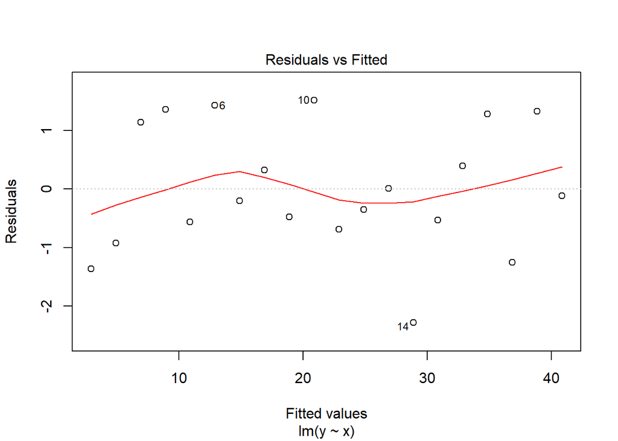

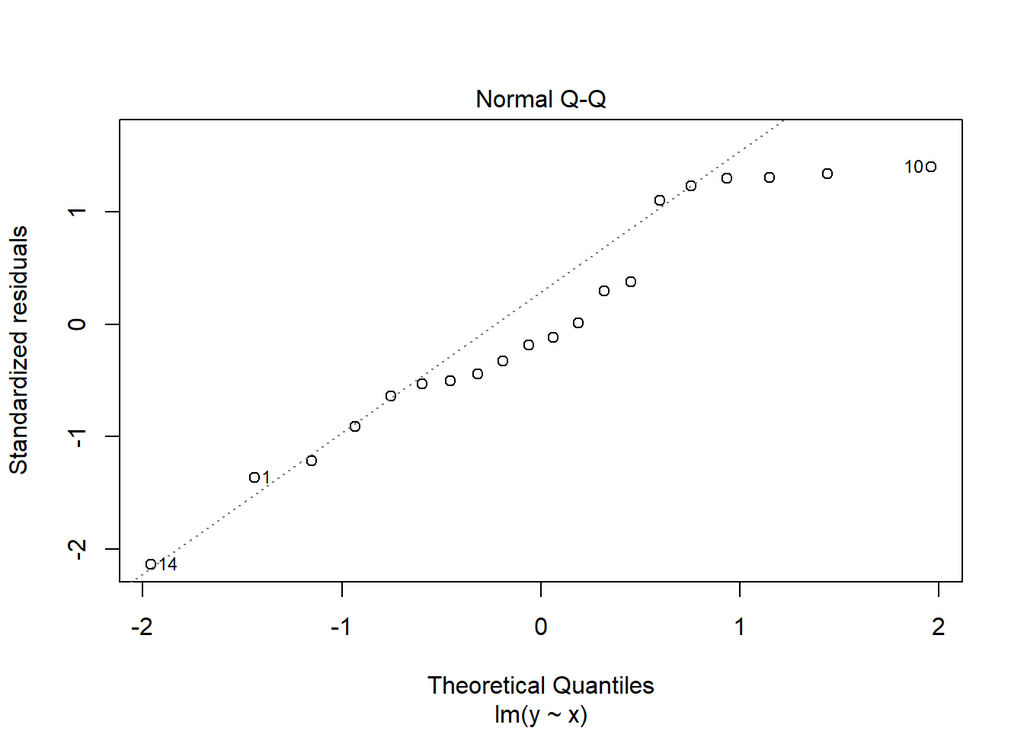

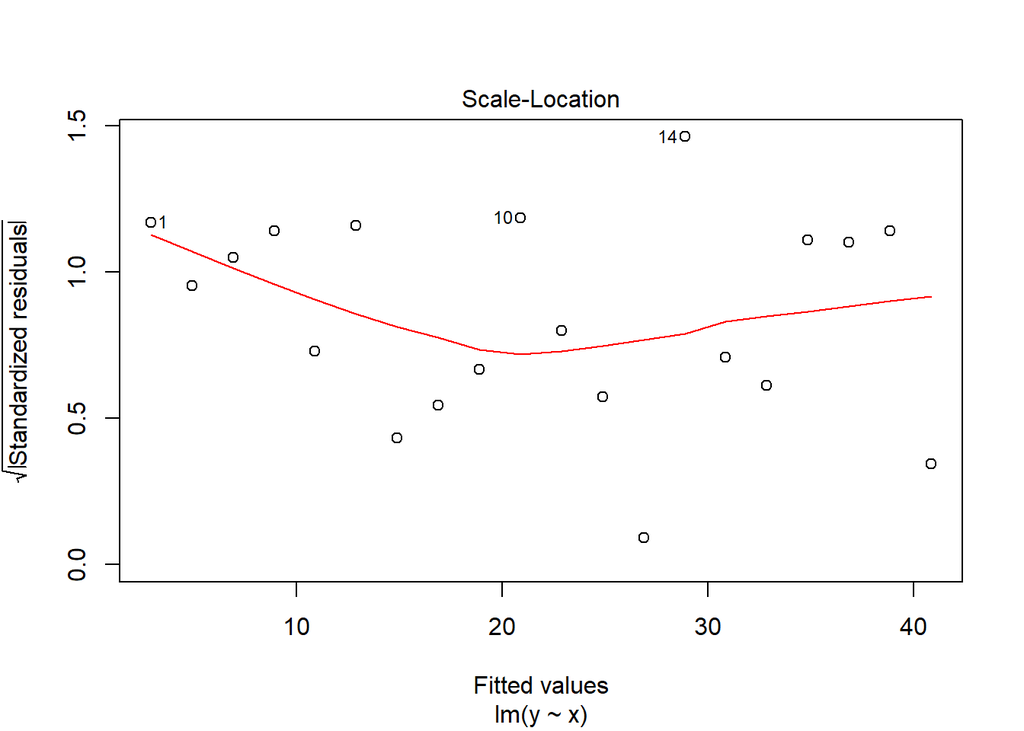

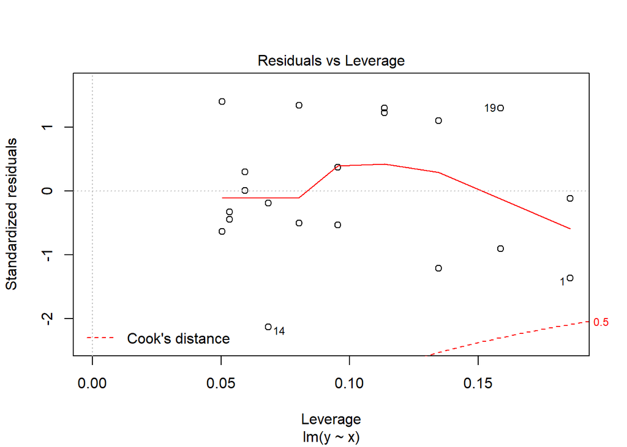

```r
plot(fit1)
```

Now we’ll add a another data point which has high leverage.

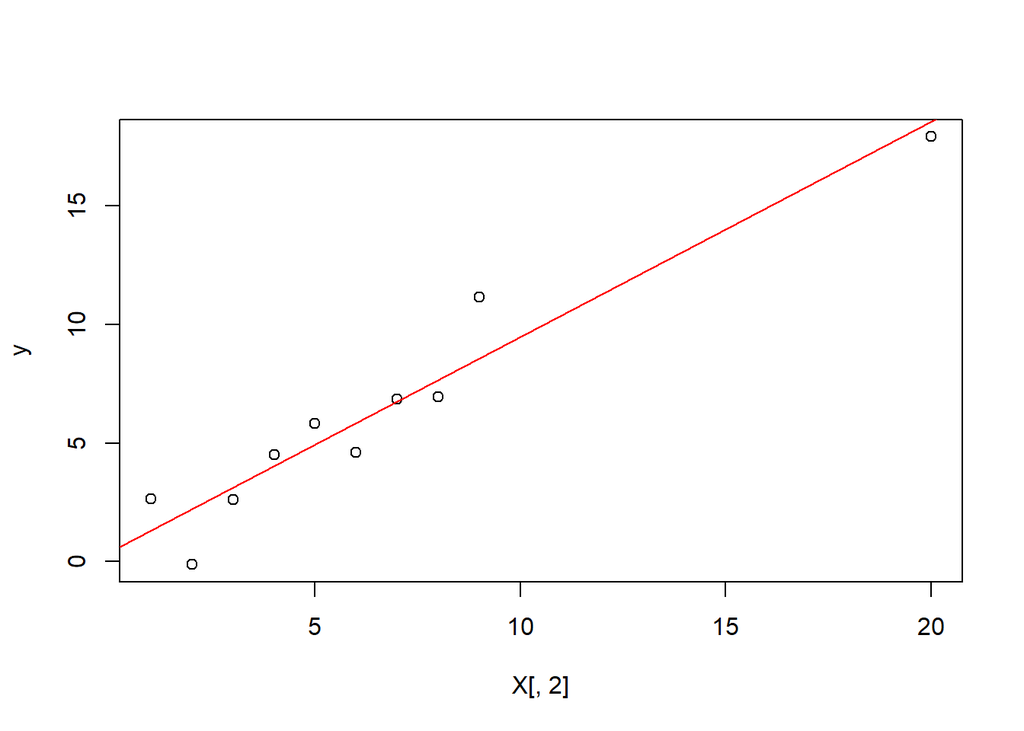

```r
# Now we add a high-leverage point
X = matrix(c(rep(1,10),1:10),ncol = 2)
X[10,2] = 20
y = X[,2] + rnorm(10)
plot(X[,2],y)
myfit = lm(y ~ X[,2])
abline(myfit, col = 2)
```

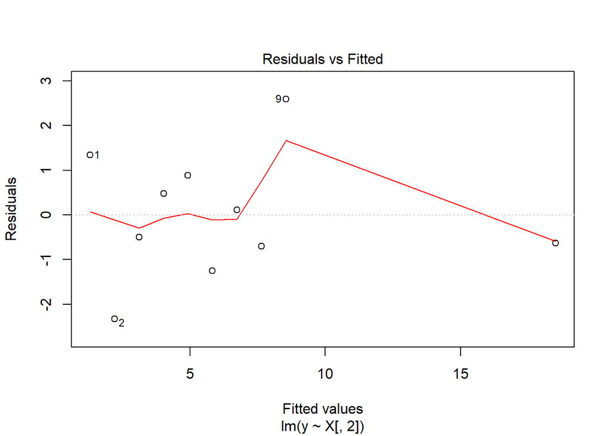

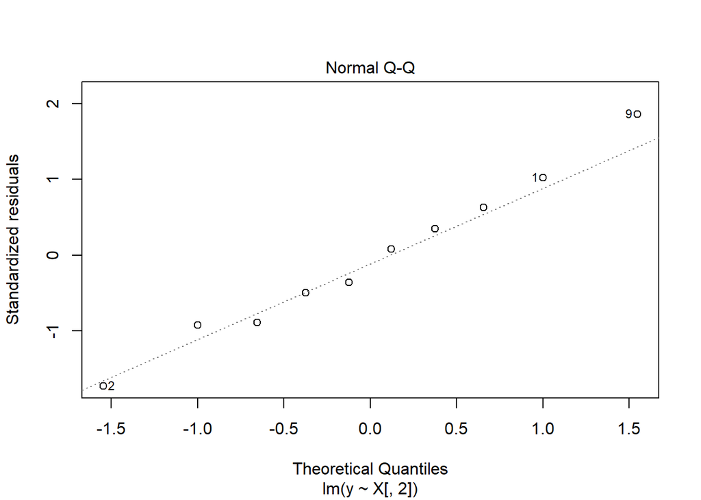

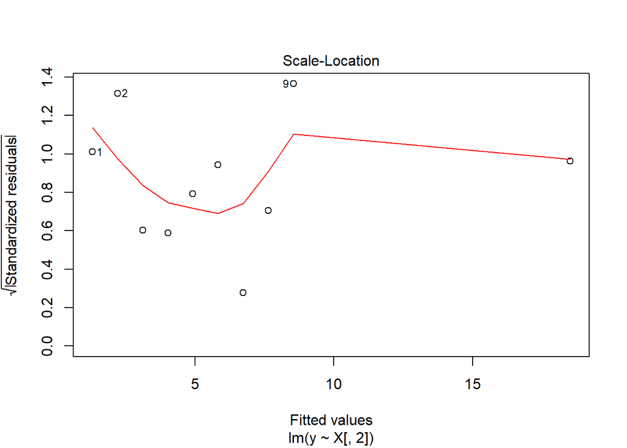

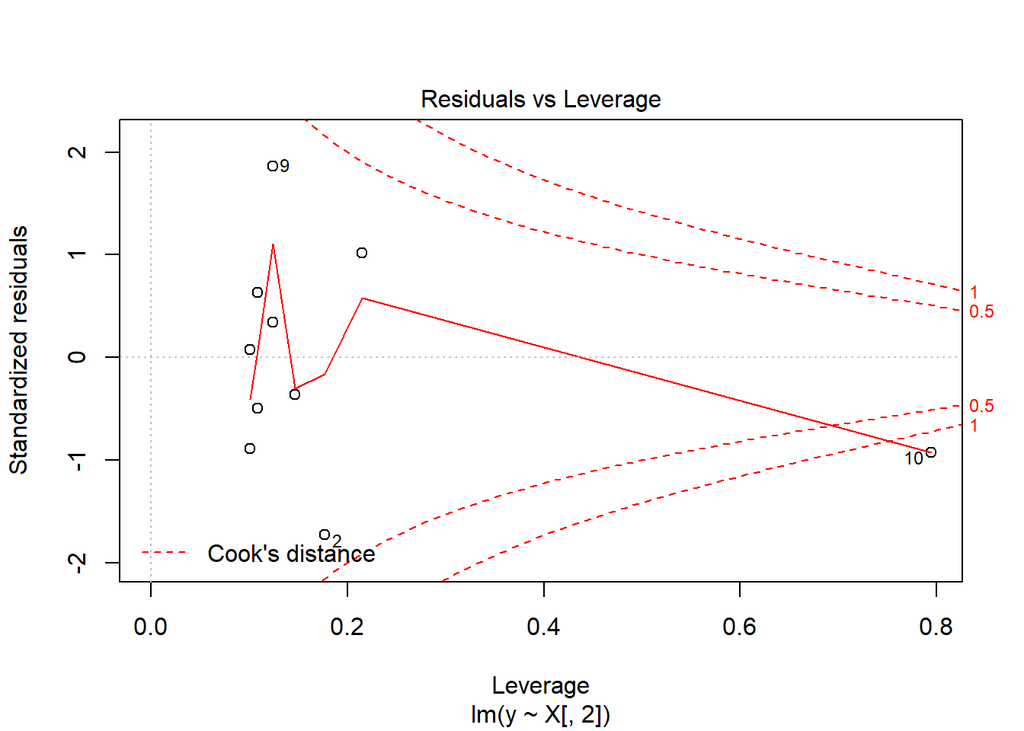

```r
plot(myfit)
```

```r
# notice that the new point has leverage of nearly 1, and residual of nearly 0.
# It will "pull the the squares line towards its observation".
# Therefore, its residual is typically not very large.
```

Collinearity

```r
delta = .1
x1 = rnorm(100)
x2 = x1 + delta*rnorm(100)
cor(x1,x2)
```

```
## [1] 0.9952376
```

```r
# Now make a response that depends on both predictors.

y <- 1 + 2*x1 + 3*x2 + rnorm(100)
fit0 <- lm(y ~ x1+x2)
summary(fit0)
```

```
##
## Call:
## lm(formula = y ~ x1 + x2)
##
## Residuals:
##     Min      1Q  Median      3Q     Max
## -3.5749 -0.6630  0.0809  0.6592  2.1302
##
## Coefficients:
##             Estimate Std. Error t value Pr(>|t|)
## (Intercept)   0.9973     0.1048   9.518 1.47e-15 ***
## x1            0.7635     1.0506   0.727 0.469123
## x2            4.2587     1.0586   4.023 0.000114 ***
## ---
## Signif. codes:  0 '***' 0.001 '**' 0.01 '*' 0.05 '.' 0.1 ' ' 1
##
## Residual standard error: 1.04 on 97 degrees of freedom
## Multiple R-squared:  0.9607, Adjusted R-squared:  0.9599
## F-statistic:  1186 on 2 and 97 DF,  p-value: < 2.2e-16
```

Note R^2 and F for the total model. Yet one of the predictors has low t-score and p-value. And also, look at the estimated coefficients. Collinear predictors can result in mis-estimation of the coefficients.